# Notebook

b. Do a formal unit root analysis to find out if these time series are stationary.

```
Total de observaciones: 234

============================================================
PRUEBA DE ESTACIONARIEDAD: TB3M
============================================================
ADF Test (H0: tiene raíz unitaria)
   Estadístico: -1.539186
   p-value: 0.514045
   Críticos: 1%=-3.460, 5%=-2.875, 10%=-2.574
   → ADF: NO ESTACIONARIA (p < 0.05)

KPSS Test (H0: es estacionaria)
   Estadístico: 1.453991
   p-value: 0.010000
   Críticos: 1%=0.739, 5%=0.463, 10%=0.347
   → KPSS: NO ESTACIONARIA (p > 0.05)

Conclusión combinada:
   Serie NO ESTACIONARIA (raíz unitaria o tendencia)

============================================================
PRUEBA DE ESTACIONARIEDAD: TB6M
============================================================
ADF Test (H0: tiene raíz unitaria)
   Estadístico: -3.773819
   p-value: 0.003187
   Críticos: 1%=-3.459, 5%=-2.874, 10%=-2.573
   → ADF: ESTACIONARIA (p < 0.05)

KPSS Test (H0: es estacionaria)
   Estadístico: 1.496086
   p-value: 0.010000
   Críticos: 1%=0.739, 5%=0.463, 10%=0.347
   → KPSS: NO ESTACIONARIA (p > 0.05)

Conclusión combinada:
   Resultados mixtos → revisar diferenciación
```

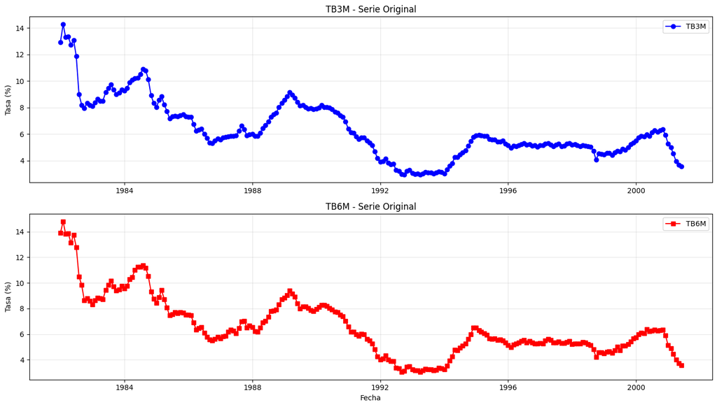

```
============================================================
DIFERENCIACIÓN DE PRIMER ORDEN (si no es estacionaria)
============================================================
Diferenciación aplicada: 234 → 233 obs.

============================================================
PRUEBA DE ESTACIONARIEDAD: TB3M (diferenciada)
============================================================
ADF Test (H0: tiene raíz unitaria)
   Estadístico: -5.573440
   p-value: 0.000001
   Críticos: 1%=-3.460, 5%=-2.875, 10%=-2.574
   → ADF: ESTACIONARIA (p < 0.05)

KPSS Test (H0: es estacionaria)
   Estadístico: 0.144372
   p-value: 0.100000
   Críticos: 1%=0.739, 5%=0.463, 10%=0.347
   → KPSS: ESTACIONARIA (p > 0.05)

Conclusión combinada:
   Serie ESTACIONARIA (ambas pruebas coinciden)

============================================================
PRUEBA DE ESTACIONARIEDAD: TB6M (diferenciada)
============================================================
ADF Test (H0: tiene raíz unitaria)
   Estadístico: -7.981793
   p-value: 0.000000
   Críticos: 1%=-3.459, 5%=-2.874, 10%=-2.573
   → ADF: ESTACIONARIA (p < 0.05)

KPSS Test (H0: es estacionaria)
   Estadístico: 0.160881
   p-value: 0.100000
   Críticos: 1%=0.739, 5%=0.463, 10%=0.347
   → KPSS: ESTACIONARIA (p > 0.05)

Conclusión combinada:
   Serie ESTACIONARIA (ambas pruebas coinciden)
```

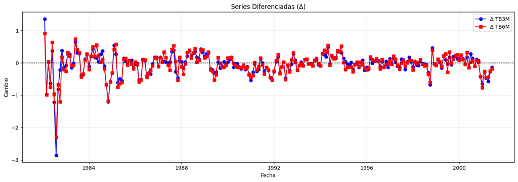

```python
# === VERIFICAR QUE df_clean EXISTE ===
if 'df_clean' not in globals():
    raise NameError("df_clean no está definido. Asegúrate de haber ejecutado el código anterior que carga y limpia los datos.")

# === IMPORTAR LIBRERÍAS NECESARIAS ===
from statsmodels.tsa.stattools import adfuller, kpss
import matplotlib.pyplot as plt
import warnings
warnings.filterwarnings("ignore")

# === FUNCIÓN PARA PRUEBAS DE ESTACIONARIEDAD ===
def test_stationarity(series, name, confidence=0.05):
    print(f"\n{'='*60}")
    print(f"PRUEBA DE ESTACIONARIEDAD: {name}")
    print(f"{'='*60}")

    # --- ADF Test ---
    adf = adfuller(series, autolag='AIC')
    print(f"ADF Test (H0: tiene raíz unitaria)")
    print(f"   Estadístico: {adf[0]:.6f}")
    print(f"   p-value: {adf[1]:.6f}")
    print(f"   Críticos: 1%={adf[4]['1%']:.3f}, 5%={adf[4]['5%']:.3f}, 10%={adf[4]['10%']:.3f}")
    adf_decision = "ESTACIONARIA" if adf[1] < confidence else "NO ESTACIONARIA"
    print(f"   → ADF: {adf_decision} (p < 0.05)")

    # --- KPSS Test ---
    kpss_stat, p_value, lags, crit = kpss(series, regression='c', nlags="auto")
    print(f"\nKPSS Test (H0: es estacionaria)")
    print(f"   Estadístico: {kpss_stat:.6f}")
    print(f"   p-value: {p_value:.6f}")
    print(f"   Críticos: 1%={crit['1%']:.3f}, 5%={crit['5%']:.3f}, 10%={crit['10%']:.3f}")
    kpss_decision = "ESTACIONARIA" if p_value > confidence else "NO ESTACIONARIA"
    print(f"   → KPSS: {kpss_decision} (p > 0.05)")

    # --- Conclusión combinada ---
    print(f"\nConclusión combinada:")
    if adf[1] < 0.05 and p_value > 0.05:
        print("   Serie ESTACIONARIA (ambas pruebas coinciden)")
    elif adf[1] > 0.05 and p_value < 0.05:
        print("   Serie NO ESTACIONARIA (raíz unitaria o tendencia)")
    else:
        print("   Resultados mixtos → revisar diferenciación")

    return adf, (kpss_stat, p_value, lags, crit)

# === EJECUTAR PRUEBAS ===
print(f"Total de observaciones: {len(df_clean)}")
adf_tb3m, kpss_tb3m = test_stationarity(df_clean['TB3M'], "TB3M")
adf_tb6m, kpss_tb6m = test_stationarity(df_clean['TB6M'], "TB6M")

# === GRAFICAR SERIES ORIGINALES ===
plt.figure(figsize=(14, 8))

plt.subplot(2, 1, 1)
plt.plot(df_clean['DATE'], df_clean['TB3M'], 'o-', label='TB3M', color='blue')
plt.title('TB3M - Serie Original')
plt.ylabel('Tasa (%)')
plt.grid(alpha=0.3)
plt.legend()

plt.subplot(2, 1, 2)
plt.plot(df_clean['DATE'], df_clean['TB6M'], 's-', label='TB6M', color='red')
plt.title('TB6M - Serie Original')
plt.xlabel('Fecha')
plt.ylabel('Tasa (%)')
plt.grid(alpha=0.3)
plt.legend()

plt.tight_layout()
plt.show()

# === DIFERENCIACIÓN AUTOMÁTICA SI ES NECESARIO ===
print(f"\n{'='*60}")
print("DIFERENCIACIÓN DE PRIMER ORDEN (si no es estacionaria)")
print(f"{'='*60}")

df_diff = df_clean.copy()
df_diff['TB3M_diff'] = df_clean['TB3M'].diff()
df_diff['TB6M_diff'] = df_clean['TB6M'].diff()
df_diff = df_diff.dropna()

if len(df_diff) > 5:  # Mínimo para pruebas
    print(f"Diferenciación aplicada: {len(df_clean)} → {len(df_diff)} obs.")
    test_stationarity(df_diff['TB3M_diff'], "TB3M (diferenciada)")
    test_stationarity(df_diff['TB6M_diff'], "TB6M (diferenciada)")

    # Graficar diferenciadas
    plt.figure(figsize=(14, 5))
    plt.plot(df_clean['DATE'].iloc[1:], df_diff['TB3M_diff'], 'o-', label='Δ TB3M', color='blue')
    plt.plot(df_clean['DATE'].iloc[1:], df_diff['TB6M_diff'], 's-', label='Δ TB6M', color='red')
    plt.axhline(0, color='black', linewidth=0.8, linestyle='--')
    plt.title('Series Diferenciadas (Δ)')
    plt.xlabel('Fecha')
    plt.ylabel('Cambio')
    plt.legend()
    plt.grid(alpha=0.3)
    plt.tight_layout()
    plt.show()
else:
    print("No hay suficientes datos para diferenciación.")
```

Are the two time series cointegrated? How do you know? Show the necessary calculations.

```
============================================================
PRUEBA DE COINTEGRACIÓN (Engle-Granger)
============================================================
Regresión: TB6M = -0.0457 + 1.0466 * TB3M + ε
R² = 0.9922
                            OLS Regression Results
==============================================================================
Dep. Variable:                      y   R-squared:                       0.992
Model:                            OLS   Adj. R-squared:                  0.992
Method:                 Least Squares   F-statistic:                 2.945e+04
Date:                Sat, 01 Nov 2025   Prob (F-statistic):          1.99e-246
Time:                        04:45:23   Log-Likelihood:                 40.346
No. Observations:                 234   AIC:                            -76.69
Df Residuals:                     232   BIC:                            -69.78
Df Model:                           1
Covariance Type:            nonrobust
==============================================================================
                 coef    std err          t      P>|t|      [0.025      0.975]
------------------------------------------------------------------------------
const         -0.0457      0.041     -1.121      0.264      -0.126       0.035
x1             1.0466      0.006    171.624      0.000       1.035       1.059
==============================================================================
Omnibus:                      136.833   Durbin-Watson:                   0.406
Prob(Omnibus):                  0.000   Jarque-Bera (JB):             1196.555
Skew:                           2.156   Prob(JB):                    1.48e-260
Kurtosis:                      13.204   Cond. No.                         20.8
==============================================================================

Notes:
[1] Standard Errors assume that the covariance matrix of the errors is correctly specified.

ADF sobre residuos (H0: residuos tienen raíz unitaria → NO cointegrados)
   Estadístico ADF: -4.690571
   p-value: 0.000088
   Valores críticos:
      1%: -3.4591
      5%: -2.8742
      10%: -2.5735

→ CONCLUSIÓN: p-value = 0.0001 < 0.05
   Los residuos son ESTACIONARIOS → SÍ HAY COINTEGRACIÓN
   TB3M y TB6M están cointegradas → relación de largo plazo estable
```

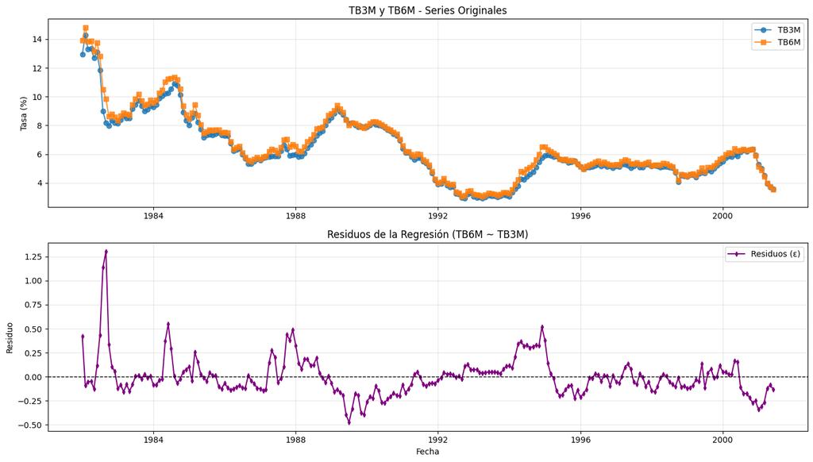

```
Relación de equilibrio estimada:
   TB6M = -0.0457 + 1.0466 × TB3M
   Desviación actual del equilibrio: ε_t = TB6M - (β₀ + β₁×TB3M)
```

```python
# === VERIFICAR QUE df_clean EXISTE ===
if 'df_clean' not in globals():
    raise NameError("Error: df_clean no está definido. Ejecuta primero el código de carga y limpieza.")

# === IMPORTAR LIBRERÍAS ===
import statsmodels.api as sm
from statsmodels.tsa.stattools import adfuller
import matplotlib.pyplot as plt
import numpy as np

# === EXTRAER SERIES ===
y = df_clean['TB6M'].values  # Dependiente
X = df_clean['TB3M'].values  # Independiente

# === PASO 1: Regresión OLS (TB6M ~ TB3M) ===
X_const = sm.add_constant(X)  # Añadir intercepto
model = sm.OLS(y, X_const).fit()

# Obtener residuos
residuals = model.resid
beta_0 = model.params[0]
beta_1 = model.params[1]

print(f"\n{'='*60}")
print("PRUEBA DE COINTEGRACIÓN (Engle-Granger)")
print(f"{'='*60}")
print(f"Regresión: TB6M = {beta_0:.4f} + {beta_1:.4f} * TB3M + ε")
print(f"R² = {model.rsquared:.4f}")
print(model.summary())

# === PASO 2: Prueba ADF sobre los residuos ===
adf_resid = adfuller(residuals, autolag='AIC')
print(f"\nADF sobre residuos (H0: residuos tienen raíz unitaria → NO cointegrados)")
print(f"   Estadístico ADF: {adf_resid[0]:.6f}")
print(f"   p-value: {adf_resid[1]:.6f}")
print(f"   Valores críticos:")
for key, val in adf_resid[4].items():
    print(f"      {key}: {val:.4f}")

# === DECISIÓN DE COINTEGRACIÓN ===
p_value = adf_resid[1]
if p_value < 0.05:
    print(f"\n→ CONCLUSIÓN: p-value = {p_value:.4f} < 0.05")
    print("   Los residuos son ESTACIONARIOS → SÍ HAY COINTEGRACIÓN")
    print("   TB3M y TB6M están cointegradas → relación de largo plazo estable")
else:
    print(f"\n→ CONCLUSIÓN: p-value = {p_value:.4f} ≥ 0.05")
    print("   Los residuos NO son estacionarios → NO HAY COINTEGRACIÓN")
    print("   No existe relación de equilibrio a largo plazo")

# === GRAFICAR RESIDUOS ===
plt.figure(figsize=(14, 8))

# Serie original
plt.subplot(2, 1, 1)
plt.plot(df_clean['DATE'], df_clean['TB3M'], 'o-', label='TB3M', alpha=0.8)
plt.plot(df_clean['DATE'], df_clean['TB6M'], 's-', label='TB6M', alpha=0.8)
plt.title('TB3M y TB6M - Series Originales')
plt.ylabel('Tasa (%)')
plt.legend()
plt.grid(alpha=0.3)

# Residuos
plt.subplot(2, 1, 2)
plt.plot(df_clean['DATE'], residuals, 'd-', color='purple', label='Residuos (ε)', markersize=4)
plt.axhline(0, color='black', linestyle='--', linewidth=1)
plt.title('Residuos de la Regresión (TB6M ~ TB3M)')
plt.xlabel('Fecha')
plt.ylabel('Residuo')
plt.legend()
plt.grid(alpha=0.3)

plt.tight_layout()
plt.show()

# === OPCIONAL: RELACIÓN DE LARGO PLAZO (si hay cointegración) ===
if p_value < 0.05:
    print(f"\nRelación de equilibrio estimada:")
    print(f"   TB6M = {beta_0:.4f} + {beta_1:.4f} × TB3M")
    print(f"   Desviación actual del equilibrio: ε_t = TB6M - (β₀ + β₁×TB3M)")
```

d. What is the economic meaning of cointegration in the present context? If the two series are not cointegrated, what are the economic implications? and. If you want to estimate a VAR model, say, with four lags of each variable, do you have to use the first differences of the two series or can you do the analysis in levels of the two series? Justify your answer.

el que estén cointegradas en el ambiente económico significa que ambas son afectadas por las decisiones económicas, políticas.

el usar el VAR en primeras diferencias omitiría las variables estacionarias que pueden ser importantes y como resultado las estimaciones podrían tener un sesgo.

```python
# PARA EXPORTAR

from google.colab import files
import nbformat
from nbconvert import HTMLExporter

# Paso 1: Cargar tu archivo .ipynb
print("Por favor, selecciona tu archivo .ipynb")
uploaded = files.upload()

# Paso 2: Obtener el nombre del archivo cargado
notebook_filename = list(uploaded.keys())[0]
print(f"\nArchivo cargado: {notebook_filename}")

# Paso 3: Leer el notebook
with open(notebook_filename, 'r', encoding='utf-8') as f:
    notebook = nbformat.read(f, as_version=4)

# Paso 4: Convertir a HTML
print("Convirtiendo a HTML...")
html_exporter = HTMLExporter()
html_exporter.template_name = 'classic'
(body, resources) = html_exporter.from_notebook_node(notebook)

# Paso 5: Guardar el archivo HTML
html_filename = notebook_filename.replace('.ipynb', '.html')
with open(html_filename, 'w', encoding='utf-8') as f:
    f.write(body)

print(f"Conversión completada: {html_filename}")

# Paso 6: Descargar el archivo HTML
print("Descargando archivo HTML...")
files.download(html_filename)
print("¡Listo! Tu archivo HTML ha sido descargado.")
```

```
Por favor, selecciona tu archivo .ipynb
```

Upload widget is only available when the cell has been executed in the current browser session. Please rerun this cell to enable.

[output not shown]